# 1008 class

River Sung

08/10/2024

# Data types and structures

## Core data types

Aka “modes”  
`typeof` - determine the mode of the object  
`mode` - also determine the mode of the object, but cannot distinguish between **integers** and **doubles**

### Numeric

**Numeric** data type is the simplest. It contains **integers** or **doubles**  
**Integers** - whole numbers  
**Doubles** - decimal numbers

```r
x <- c(1.0, -3.4, 2, 140.1) # numeric and double

typeof(x) #using this function to determine what mode/data type x is
```

```
## [1] "double"
```

```r
mode(x) #does not distinguish integers and doubles
```

```
## [1] "numeric"
```

```r
#Removing decimal does not make a double into an integer.
#For example:
typeof(5)
```

```
## [1] "double"
```

Therefore, for R to recognize a value as integer, we add a capital L

```r
x <- 5L
typeof(x)
```

```
## [1] "integer"
```

### Character

Mostly seen as letters or words.

```r
x <- c("bubul", "magpie", "spoonbill", "barbet")
typeof(x)
```

```
## [1] "character"
```

```r
# Can also be two numeric vector
x <- 3
y <- 5.3
x + y
```

```
## [1] 8.3
```

When ” ” is used, R interprets them as characters, but some functions like `plot(x, y)` automatically converts characters to doubles.

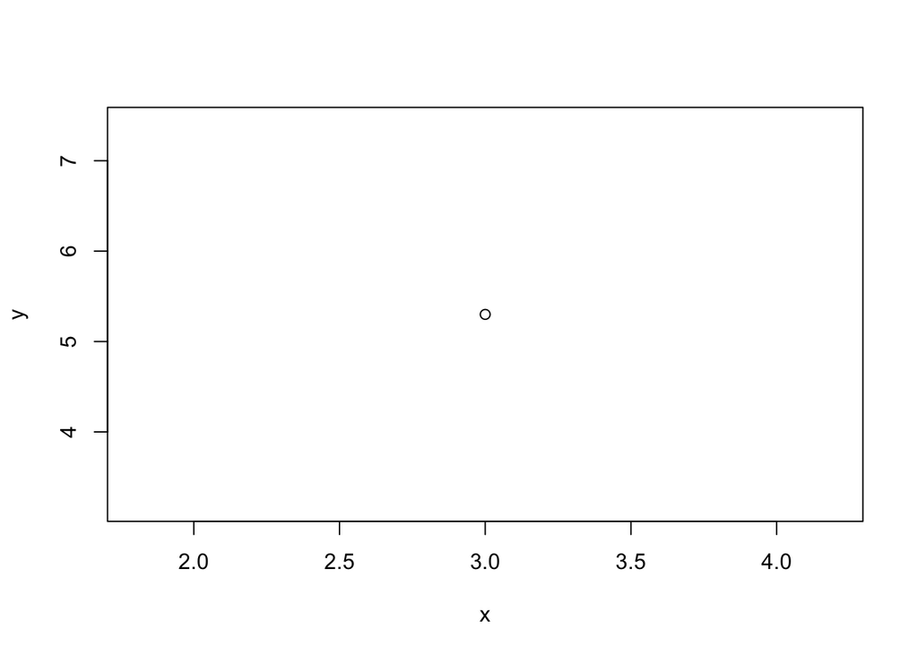

```r
x <- "3"
y <- "5.3"

# x+ y
# Error in x + y : non-numeric argument to binary operator
plot(x, y)
```

### Logical

`TRUE` or `FALSE` conditions, also `1` or `0`

```r
# full text:
x <- c(TRUE, FALSE, FALSE, TRUE)
# or in short:
x <- c(T, F, F, T)
# or binary
x1<-c(1,0,0,1)
x2 <- as.logical(c(1,0,0,1)) #converts internally to T or F
# OR: x3 <- as.logical(c(1,0,0,1))
```

## Derived data types

```r
a <- c("M", "F", "F", "U", "F", "M", "M", "M", "F", "U")
typeof(a) # mode character
```

```
## [1] "character"
```

```r
class(a) # class character
```

```
## [1] "character"
```

```r
a.fact <- as.factor(a)
class(a.fact) # class factor
```

```
## [1] "factor"
```

**Note**: a has not changed the mode. The data is still of the type `character`. However, it may seem strange at first, but the derived object `a.fact` is now stored as an `integer`!

```r
mode(a.fact)
```

```
## [1] "numeric"
```

```r
typeof(a.fact)
```

```
## [1] "integer"
```

```r
a.fact
```

```
##  [1] M F F U F M M M F U
## Levels: F M U
```

`a.fact` is stored as `interger`, even though it’s displayed as factors (characters), because `a.fact` is more complicated. `Factor`stores additional information not visible in output. Hidden information is stored in `attributes`

```r
attributes(a.fact)
```

```
## $levels
## [1] "F" "M" "U"
##
## $class
## [1] "factor"
```

```r
levels(a.fact)
```

```
## [1] "F" "M" "U"
```

There are two attributes: `levels` and `class`. The `levels` attribute lists unique values in alpha-numeric order. **If we need to rearrange for display and graphing purposes, must change it by recreating the factor object:**

```r
factor(a, levels=c("U", "F", "M"))
```

```
##  [1] M F F U F M M M F U
## Levels: U F M
```

Practice 3.1

```r
str(iris)
```

```
## 'data.frame':    150 obs. of  5 variables:
##  $ Sepal.Length: num  5.1 4.9 4.7 4.6 5 5.4 4.6 5 4.4 4.9 ...
##  $ Sepal.Width : num  3.5 3 3.2 3.1 3.6 3.9 3.4 3.4 2.9 3.1 ...
##  $ Petal.Length: num  1.4 1.4 1.3 1.5 1.4 1.7 1.4 1.5 1.4 1.5 ...
##  $ Petal.Width : num  0.2 0.2 0.2 0.2 0.2 0.4 0.3 0.2 0.2 0.1 ...
##  $ Species     : Factor w/ 3 levels "setosa","versicolor",..: 1 1 1 1 1 1 1 1 1 1 ...
```

```r
iris.sel <- subset(iris, Species == "setosa" | Species == "virginica") #subsetting thw two species
iris.sel
```

```
##     Sepal.Length Sepal.Width Petal.Length Petal.Width   Species
## 1            5.1         3.5          1.4         0.2    setosa
## 2            4.9         3.0          1.4         0.2    setosa
## 3            4.7         3.2          1.3         0.2    setosa
## 4            4.6         3.1          1.5         0.2    setosa
## 5            5.0         3.6          1.4         0.2    setosa
## 6            5.4         3.9          1.7         0.4    setosa
## 7            4.6         3.4          1.4         0.3    setosa
## 8            5.0         3.4          1.5         0.2    setosa
## 9            4.4         2.9          1.4         0.2    setosa
## 10           4.9         3.1          1.5         0.1    setosa
## 11           5.4         3.7          1.5         0.2    setosa
## 12           4.8         3.4          1.6         0.2    setosa
## 13           4.8         3.0          1.4         0.1    setosa
## 14           4.3         3.0          1.1         0.1    setosa
```

[output cut: 86 more lines]

```r
levels(iris.sel$Species) # even though it's been subset, the third species from original dataset is still present
```

```
## [1] "setosa"     "versicolor" "virginica"
```

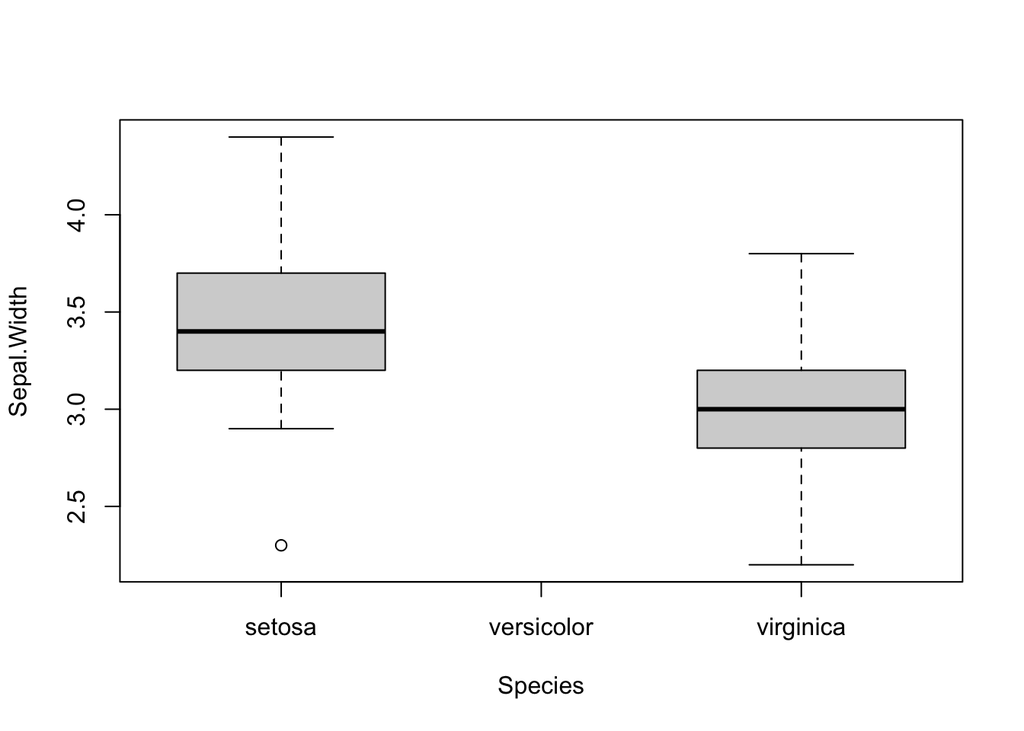

```r
boxplot(Sepal.Width~Species, data=iris.sel)
```

Plotting graph allows us to visualize that there’s an empty column, which is bad. Need to get rid of it by using the `droplevels` function.

```r
iris.sel$Species <- droplevels(iris.sel$Species)
iris.sel
```

```
##     Sepal.Length Sepal.Width Petal.Length Petal.Width   Species
## 1            5.1         3.5          1.4         0.2    setosa
## 2            4.9         3.0          1.4         0.2    setosa
## 3            4.7         3.2          1.3         0.2    setosa
## 4            4.6         3.1          1.5         0.2    setosa
## 5            5.0         3.6          1.4         0.2    setosa
## 6            5.4         3.9          1.7         0.4    setosa
## 7            4.6         3.4          1.4         0.3    setosa
## 8            5.0         3.4          1.5         0.2    setosa
## 9            4.4         2.9          1.4         0.2    setosa
## 10           4.9         3.1          1.5         0.1    setosa
## 11           5.4         3.7          1.5         0.2    setosa
## 12           4.8         3.4          1.6         0.2    setosa
## 13           4.8         3.0          1.4         0.1    setosa
## 14           4.3         3.0          1.1         0.1    setosa
```

[output cut: 86 more lines]

```r
levels(iris.sel$Species) # now that there are only two levels present in the dataset
```

```
## [1] "setosa"    "virginica"
```

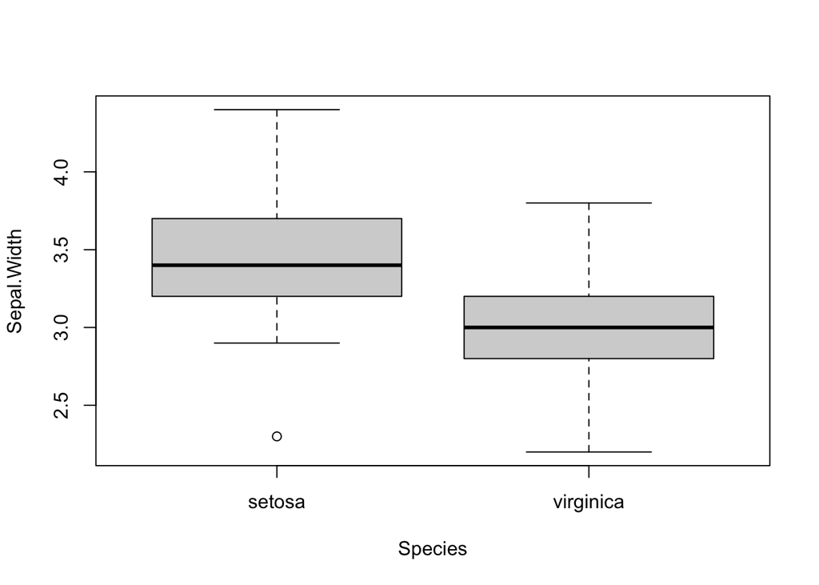

```r
boxplot(Sepal.Width~Species, data=iris.sel) # graph fixed!
```

```r
rownames(iris.sel) = seq(length=nrow(iris.sel)) #wait i'm not sure what this is for
```

### Date

Values stored as numbers. To be properly interpreted as a date object in R, their attribute must be explicitly defined as **date**. There is a package called `lubricate`. This topic will not be covered.

### NAs and NULLs

Missing or unknown values in dataset does not equal to 0.  
NA - not available: missing value, data should be there, but we are unable to retrieve it.  
NULL - also missing values, but means value does not exist or not measurable.  
When doing analysis, this could lead to very different results.

```r
x <- c(23, NA, 1.2, 5)
y <- c(23, NULL, 1.2, 5)
mean(x) # cannot take the mean of NA values
```

```
## [1] NA
```

```r
mean(y)
```

```
## [1] 9.733333
```

Can use the `na.rm` function to ignore NA values

```r
mean(x, na.rm = T) #works! now can calculate the mean even if the value is NA
```

```
## [1] 9.733333
```

## Data Structures

There are different such as **table** or a **list** of results. They are stored in R in one of several data structures.

### (Atomic) vectors

Consist of an ordered set of values of the same type or class (numeric, character, date). **Vector can be created with the combination function `c()`**

```r
x <- c(674 , 4186 , 5308 , 5083 , 6140 , 6381)
x
```

```
## [1]  674 4186 5308 5083 6140 6381
```

```r
x[3] # access the third element of x, use [ ]
```

```
## [1] 5308
```

```r
x[c(1,3,4)] # select a subset of elements by index values using `c()`
```

```
## [1]  674 5308 5083
```

```r
x[2:4] # select a range of element like index 2-4 use the operator :
```

```
## [1] 4186 5308 5083
```

```r
x[2] <- 0 # assign value to the second index - replace
x
```

```
## [1]  674    0 5308 5083 6140 6381
```

```r
x <- c("all", "b", "olive") # can store other data type, like characters
x
```

```
## [1] "all"   "b"     "olive"
```

```r
x <- c( 1.2, 5, "Rt", "2000") # can only be of one type, cannot mix numeric and character type
typeof(x)
```

```
## [1] "character"
```

When more than two data types are given at once, highest common mode is used. **NULL < logical < integer < double < character**

### Matrices and arrays

Vectors that are indexted with two indices instead of one. Following: 3x3 matrix with generated values. `nrow` and `ncol` define dimension and `runif` generates 9 values between 0-10

```r
m <- matrix(runif(9,0,10), nrow = 3, ncol = 3)
m
```

```
##          [,1]     [,2]     [,3]
## [1,] 4.275364 4.210549 1.506204
## [2,] 1.205676 1.840091 5.666379
## [3,] 6.986481 5.291443 9.641008
```

Higher dimensions, use `array` function to create n-dimensional matrix. 3x3x3 can be created.

```r
m <- array(runif(27,0,10), c(3,3,3))
m
```

```
## , , 1
##
##          [,1]     [,2]     [,3]
## [1,] 8.831630 7.020462 9.909183
## [2,] 5.587424 4.297525 4.800580
## [3,] 9.178982 7.318337 3.480027
##
## , , 2
##
##           [,1]     [,2]      [,3]
## [1,] 4.0665975 9.781666 9.0411305
## [2,] 5.9572843 4.814303 0.2941707
## [3,] 0.1653932 8.678268 6.5829939
##
## , , 3
##
##          [,1]     [,2]     [,3]
## [1,] 5.238926 7.309046 9.231989
## [2,] 7.263935 2.160022 1.855148
## [3,] 7.847995 4.794270 1.541070
```

Matrices and arrays can store numeric or character data types, but not both at once.

### Data frames

Close to a table, but can mix data types across columns (both numeric and character columns can coexist in a data frame). Data type same across rows

```r
name   <- c("a1", "a2", "b3")
value1 <- c(23, 4, 12)
value2 <- c(1, 45, 5)
dat    <- data.frame(name, value1, value2)
dat
```

```
##   name value1 value2
## 1   a1     23      1
## 2   a2      4     45
## 3   b3     12      5
```

```r
str(dat)
```

```
## 'data.frame':    3 obs. of  3 variables:
##  $ name  : chr  "a1" "a2" "b3"
##  $ value1: num  23 4 12
##  $ value2: num  1 45 5
```

```r
attributes(dat)
```

```
## $names
## [1] "name"   "value1" "value2"
##
## $class
## [1] "data.frame"
##
## $row.names
## [1] 1 2 3
```

```r
names(dat) # extract column names
```

```
## [1] "name"   "value1" "value2"
```

```r
rownames(dat) # extract row names
```

```
## [1] "1" "2" "3"
```

### Lists

An ordered set of components stored in 1D vector. It’s a **recursive vector**, where each vector element can have a different data type and structure. Each element of a list can contain complex objects such as matrix, data frames, or another list.

List can be created with the `list` function. Example:  
- A: Two-column data frame  
- B: Logical vector with two elements  
- C: Character vector with three elements

```r
A <- data.frame(
     x = c(7.3, 29.4, 29.4, 2.9, 12.3, 7.5, 36.0, 4.8, 18.8, 4.2),
     y = c(5.2, 26.6, 31.2, 2.2, 13.8, 7.8, 35.2, 8.6, 20.3, 1.1) )
B <- c(TRUE, FALSE)
C <- c("apples", "oranges", "round")
my.list <- list(A = A, B = B, C = C)
my.list
```

```
## $A
##       x    y
## 1   7.3  5.2
## 2  29.4 26.6
## 3  29.4 31.2
## 4   2.9  2.2
## 5  12.3 13.8
## 6   7.5  7.8
## 7  36.0 35.2
## 8   4.8  8.6
## 9  18.8 20.3
## 10  4.2  1.1
##
## $B
## [1]  TRUE FALSE
##
## $C
## [1] "apples"  "oranges" "round"
```

```r
names(my.list)
```

```
## [1] "A" "B" "C"
```

Each component of a list can be extracted using the $ symbol followed by that component’s name. For example, to access component A from list `my.list`, type:

```r
my.list$A
```

```
##       x    y
## 1   7.3  5.2
## 2  29.4 26.6
## 3  29.4 31.2
## 4   2.9  2.2
## 5  12.3 13.8
## 6   7.5  7.8
## 7  36.0 35.2
## 8   4.8  8.6
## 9  18.8 20.3
## 10  4.2  1.1
```

```r
# or using its numerical index

my.list[[1]] # first (1) component of the list
```

```
##       x    y
## 1   7.3  5.2
## 2  29.4 26.6
## 3  29.4 31.2
## 4   2.9  2.2
## 5  12.3 13.8
## 6   7.5  7.8
## 7  36.0 35.2
## 8   4.8  8.6
## 9  18.8 20.3
## 10  4.2  1.1
```

```r
# can also create list like this:
my.list.notags <- list(A, B, D)
my.list.notags
```

```
## [[1]]
##       x    y
## 1   7.3  5.2
## 2  29.4 26.6
## 3  29.4 31.2
## 4   2.9  2.2
## 5  12.3 13.8
## 6   7.5  7.8
## 7  36.0 35.2
## 8   4.8  8.6
## 9  18.8 20.3
## 10  4.2  1.1
##
## [[2]]
## [1]  TRUE FALSE
##
## [[3]]
## function (expr, name)
## .External(C_doD, expr, name)
## <bytecode: 0x11c86aba8>
## <environment: namespace:stats>
```

```r
names(my.list.notags) # do not have component names NULL
```

[output not shown]

If we fit a linear model between elements x and y (in the data frame A), the output of this model (M) is a list:

```r
M <- lm( y ~ x, A)
str(M)
```

```
## List of 12
##  $ coefficients : Named num [1:2] 0.0779 0.991
##   ..- attr(*, "names")= chr [1:2] "(Intercept)" "x"
##  $ residuals    : Named num [1:10] -2.112 -2.612 1.988 -0.752 1.533 ...
##   ..- attr(*, "names")= chr [1:10] "1" "2" "3" "4" ...
##  $ effects      : Named num [1:10] -48.07 -36.54 3.13 -0.66 2 ...
##   ..- attr(*, "names")= chr [1:10] "(Intercept)" "x" "" "" ...
##  $ rank         : int 2
##  $ fitted.values: Named num [1:10] 7.31 29.21 29.21 2.95 12.27 ...
##   ..- attr(*, "names")= chr [1:10] "1" "2" "3" "4" ...
##  $ assign       : int [1:2] 0 1
##  $ qr           :List of 5
##   ..$ qr   : num [1:10, 1:2] -3.162 0.316 0.316 0.316 0.316 ...
##   .. ..- attr(*, "dimnames")=List of 2
##   .. .. ..$ : chr [1:10] "1" "2" "3" "4" ...
##   .. .. ..$ : chr [1:2] "(Intercept)" "x"
##   .. ..- attr(*, "assign")= int [1:2] 0 1
##   ..$ qraux: num [1:2] 1.32 1.44
##   ..$ pivot: int [1:2] 1 2
##   ..$ tol  : num 1e-07
##   ..$ rank : int 2
##   ..- attr(*, "class")= chr "qr"
##  $ df.residual  : int 8
##  $ xlevels      : Named list()
##  $ call         : language lm(formula = y ~ x, data = A)
##  $ terms        :Classes 'terms', 'formula'  language y ~ x
##   .. ..- attr(*, "variables")= language list(y, x)
##   .. ..- attr(*, "factors")= int [1:2, 1] 0 1
##   .. .. ..- attr(*, "dimnames")=List of 2
##   .. .. .. ..$ : chr [1:2] "y" "x"
##   .. .. .. ..$ : chr "x"
##   .. ..- attr(*, "term.labels")= chr "x"
##   .. ..- attr(*, "order")= int 1
##   .. ..- attr(*, "intercept")= int 1
##   .. ..- attr(*, "response")= int 1
##   .. ..- attr(*, ".Environment")=<environment: R_GlobalEnv>
##   .. ..- attr(*, "predvars")= language list(y, x)
##   .. ..- attr(*, "dataClasses")= Named chr [1:2] "numeric" "numeric"
##   .. .. ..- attr(*, "names")= chr [1:2] "y" "x"
##  $ model        :'data.frame':   10 obs. of  2 variables:
##   ..$ y: num [1:10] 5.2 26.6 31.2 2.2 13.8 7.8 35.2 8.6 20.3 1.1
##   ..$ x: num [1:10] 7.3 29.4 29.4 2.9 12.3 7.5 36 4.8 18.8 4.2
##   ..- attr(*, "terms")=Classes 'terms', 'formula'  language y ~ x
##   .. .. ..- attr(*, "variables")= language list(y, x)
##   .. .. ..- attr(*, "factors")= int [1:2, 1] 0 1
##   .. .. .. ..- attr(*, "dimnames")=List of 2
##   .. .. .. .. ..$ : chr [1:2] "y" "x"
##   .. .. .. .. ..$ : chr "x"
##   .. .. ..- attr(*, "term.labels")= chr "x"
##   .. .. ..- attr(*, "order")= int 1
##   .. .. ..- attr(*, "intercept")= int 1
##   .. .. ..- attr(*, "response")= int 1
##   .. .. ..- attr(*, ".Environment")=<environment: R_GlobalEnv>
##   .. .. ..- attr(*, "predvars")= language list(y, x)
##   .. .. ..- attr(*, "dataClasses")= Named chr [1:2] "numeric" "numeric"
##   .. .. .. ..- attr(*, "names")= chr [1:2] "y" "x"
##  - attr(*, "class")= chr "lm"
```

```r
names(M)
```

```
##  [1] "coefficients"  "residuals"     "effects"       "rank"
##  [5] "fitted.values" "assign"        "qr"            "df.residual"
##  [9] "xlevels"       "call"          "terms"         "model"
```

```r
str(M$qr) # the element qr is a list with 5 elements
```

```
## List of 5
##  $ qr   : num [1:10, 1:2] -3.162 0.316 0.316 0.316 0.316 ...
##   ..- attr(*, "dimnames")=List of 2
##   .. ..$ : chr [1:10] "1" "2" "3" "4" ...
##   .. ..$ : chr [1:2] "(Intercept)" "x"
##   ..- attr(*, "assign")= int [1:2] 0 1
##  $ qraux: num [1:2] 1.32 1.44
##  $ pivot: int [1:2] 1 2
##  $ tol  : num 1e-07
##  $ rank : int 2
##  - attr(*, "class")= chr "qr"
```

```r
M$qr$rank # access component qr of the list M
```

```
## [1] 2
```

## Coercing data

Data can be converted from one type to another. From character -> numeric, use `as.numeric`.  
This function converts the vector into a double (can also use `as.double`). If convert y into an integer, R remove all decimals from the number.

```r
y <- c("23.8", "6", "100.01","6")
y.c <- as.numeric(y)
y.c
```

```
## [1]  23.80   6.00 100.01   6.00
```

```r
as.integer(y) # removes decimals when converting to integer
```

```
## [1]  23   6 100   6
```

```r
numchar <- as.character(y.c) # convert a number to a character
numchar
```

```
## [1] "23.8"   "6"      "100.01" "6"
```

```r
numfac <- as.factor(y) # convert a number/character into factor
numfac
```

```
## [1] 23.8   6      100.01 6
## Levels: 100.01 23.8 6
```

```r
charfac <- as.factor(y.c)
charfac
```

```
## [1] 23.8   6      100.01 6
## Levels: 6 23.8 100.01
```

Other functions:

```r
as.numeric  # Coerce to numeric
```

```
## function (x, ...)  .Primitive("as.double")
```

```r
as.double   # Coerce to double
```

```
## function (x, ...)  .Primitive("as.double")
```

```r
as.integer  # Coerce to integer
```

```
## function (x, ...)  .Primitive("as.integer")
```

```r
as.character #  Coerce to character
```

```
## function (x, ...)  .Primitive("as.character")
```

```r
as.logical  # Coerce to Boolean (logical: TRUE | FALSE)
```

```
## function (x, ...)  .Primitive("as.logical")
```

```r
as.factor   # Coerce to factor
```

```
## function (x)
## {
##     if (is.factor(x))
##         x
##     else if (!is.object(x) && is.integer(x)) {
##         levels <- sort.int(unique.default(x))
##         f <- match(x, levels)
##         levels(f) <- as.character(levels)
##         if (!is.null(nx <- names(x)))
##             names(f) <- nx
##         class(f) <- "factor"
##         f
##     }
##     else factor(x)
## }
## <bytecode: 0x1189cc9a0>
## <environment: namespace:base>
```

```r
as.Date  # Coerce to date
```

```
## function (x, ...)
## UseMethod("as.Date")
## <bytecode: 0x11a669108>
## <environment: namespace:base>
```

```r
as.data.frame  # Coerce to data frame
```

```
## function (x, row.names = NULL, optional = FALSE, ...)
## {
##     if (is.null(x))
##         return(as.data.frame(list()))
##     UseMethod("as.data.frame")
## }
## <bytecode: 0x14b398870>
## <environment: namespace:base>
```

```r
as.list # Coerce to list
```

```
## function (x, ...)
## UseMethod("as.list")
## <bytecode: 0x148925e78>
## <environment: namespace:base>
```